# Python Crash Course for Java Developers

# 💎 Input and Output

You output something with `print()` and you can read input with `input()`

```python
pi = 3.141

print(pi)
print()
print("The value of pi is", pi)
```

```
3.141

The value of pi is 3.141
```

```python
print("I ", end="")
print("hate ", end="")
print("line ", end="")
print("breaks ", end="")
```

```
I hate line breaks
```

```python
# this is a so-called format string
print(f"The value of pi is {pi} and the value of tau is {2 * pi}")
```

```
The value of pi is 3.141 and the value of tau is 6.282
```

### Number Formatting

See also https://gto76.github.io/python-cheatsheet/#format

```python
pi = 3.14159265359
ratio = 0.25

print(pi)

print()

print(f"{pi:.0f}")     # no decimal places
print(f"{pi:.2f}")     # two decimal places
print(f"{pi:.3e}")     # scientific notation

print(f"{ratio:.1%}")  # percentage
```

```
3.14159265359

3
3.14
3.142e+00
25.0%
```

```python
# name = input("Please enter your name: ")
name = "Max"
print("Your name is", name)
```

```
Your name is Max
```

```python
# this function will always give you a string
# text = input("Please enter a number: ")
text = "5"

# you need to convert the types
as_int = int(text)
as_float = float(text)

print(as_int, as_float)
```

```
5 5.0
```

# 💎 Examples, Examples, Examples

Now that we know data types, let's see a few control flow examples.

### Basic control flow

```python
%%script false --no-raise-error # ignore this Java code block

int x = 0;

switch (x) {
    case 0:
        System.out.println("The value is 0");
        break;
    case 1:
        System.out.println("The value is 1");
        break;
    case 2:
        System.out.println("The value is 2");
        break;
    default:
        System.out.println("The value is something else");
}
```

```
Couldn't find program: 'false'
```

```python
x = 0

if x == 0:
    print("The value is 0")
elif x == 1:
    print("The value is 1")
elif x == 2:
    print("The value is 2")
else:
    print("The value is something else")
```

```
The value is 0
```

**What do we notice here?**

- Python has no `switch` expression, you have to make a cascade of `if`, `elif` and `else` statements

### The sum of all digits

```python
%%script false --no-raise-error # ignore this Java code block

// int n = In.readInt();
Scanner scanner = new Scanner(System.in);
System.out.print("Enter a number: ");
int n = Integer.parseInt(scanner.nextLine());
scanner.close();

int digit_sum = 0;

while (n > 0) {
    digit_sum += n % 10;
    n = n / 10;
}

System.out.println("The digit sum is " + digit_sum);
```

```
Couldn't find program: 'false'
```

```python
# n = int(input('Enter a number: '))
n = 123
digit_sum = 0

while n > 0:
    digit_sum += n % 10
    n = n // 10

print("The digit sum is ", digit_sum)
```

```
The digit sum is  6
```

**What do we notice here?**

- Reading from user input is easier in Python with `input()`
- The `while` loop also exists in Python
- We use an explicit integer division `//` in Python, but use a normal division `/` in Java

```python
# unlike Java, a division will alwasy give you a float data type
5 / 2
```

```
2.5
```

```python
# unless you want an explicit integer division
5 // 2
```

```
2
```

### Iterating over list elements

```python
%%script false --no-raise-error # ignore this Java code block

String[] names = {"Franz", "Susanne", "Hans", "Herbert", "Peter", "Max", "Lisa"};

for (String name : names) {
    System.out.println(name);
}
```

```
Couldn't find program: 'false'
```

```python
names = ["Franz", "Susanne", "Hans", "Herbert", "Peter", "Max", "Lisa"]

for name in names:
    print(name)
```

```
Franz
Susanne
Hans
Herbert
Peter
Max
Lisa
```

### Fun with Lists

```python
%%script false --no-raise-error # ignore this Java code block

int[] numbers = {10, 11, 12, 13, 14, 15, 16, 17, 18, 19, 20};

for (int i = 5; i < 8; i++) {
    System.out.println(numbers[i]);
}
```

```
Couldn't find program: 'false'
```

```python
numbers = [10, 11, 12, 13, 14, 15, 16, 17, 18, 19, 20]

for i in range(5, 8):
    print(numbers[i])
```

```
15
16
17
```

**What do we notice here?**

- Python always requires you to use the `x in y` syntax with a `for` loop
  - To replicate the behavior you might know, you have to use `range(start, stop)` that will give you numbers from `start` to `stop - 1`
  - Actually, it will give you an **iterator** object - if you really want the numbers in a list, you have to convert it to a list

```python
range(5, 8)
```

```
range(5, 8)
```

```python
list(range(5, 8))
```

```
[5, 6, 7]
```

### Slicing

Use cases like the one above are usually solved by slicing a list with Python.

This is also very useful for mathematical applications, e.g. when working with a lot of arrays and matrices.

The following variants are supported:

- `a[start:stop:step]`
- `a[start:stop]`
- `a[start:]`
- `a[:stop]`
- `a[:]` (copy the entire list)

```python
numbers = [10, 11, 12, 13, 14, 15, 16, 17, 18, 19, 20]

# give me a new COPY of the list, starting at index 5, and ending at index 7
numbers[5:8]
```

```
[15, 16, 17]
```

```python
# everything except the first value
numbers[1:]
```

```
[11, 12, 13, 14, 15, 16, 17, 18, 19, 20]
```

```python
# everything except the last value
numbers[:-1]
```

```
[10, 11, 12, 13, 14, 15, 16, 17, 18, 19]
```

```python
# the last two items
numbers[-2:]
```

```
[19, 20]
```

```python
# give me every second value
numbers[::2]
```

```
[10, 12, 14, 16, 18, 20]
```

```python
# start with the second value, then give me every second value
numbers[1::2]
```

```
[11, 13, 15, 17, 19]
```

```python
# this also works with strings (which are just arrays of characters)
name = "Hello World"
name[1:-1]
```

```
'ello Worl'
```

### Reversing

Use `.reverse()` for in-place reversals or `reversed()` to get an reversed copy (actually, an iterator).

```python
# easily reverse any list
name[::-1]
```

```
'dlroW olleH'
```

```python
# however, most likely you should use the `reversed` function
# which, again, gives you an iterator

list(reversed(numbers))
```

```
[20, 19, 18, 17, 16, 15, 14, 13, 12, 11, 10]
```

```python
numbers = [1, -10, 20, 11, 19, 0, -5, -1000, 100, 7]

# or, reverse something in-place
numbers.reverse()
numbers
```

```
[7, 100, -1000, -5, 0, 19, 11, 20, -10, 1]
```

### Sorting

```python
numbers = [1, -10, 20, 11, 19, 0, -5, -1000, 100, 7]

sorted(numbers)
```

```
[-1000, -10, -5, 0, 1, 7, 11, 19, 20, 100]
```

```python
# or, sort something in-place
numbers.sort()
numbers
```

```
[-1000, -10, -5, 0, 1, 7, 11, 19, 20, 100]
```

```python
# and, in reverse order
sorted(numbers, reverse=True)
```

```
[100, 20, 19, 11, 7, 1, 0, -5, -10, -1000]
```

### Enumerating

```python
%%script false --no-raise-error # ignore this Java code block

String[] names = {"Franz", "Susanne", "Hans", "Herbert", "Peter", "Max", "Lisa"};

// alternative: for (int i = 0; i < names.length; i++)

int i = 0;
while (i < names.length) {
    System.out.println(i + " " + names[i]);
    i++;
}
```

```
Couldn't find program: 'false'
```

```python
names = ["Franz", "Susanne", "Hans", "Herbert", "Peter", "Max", "Lisa"]

for i, name in enumerate(names):
    print(i, name)
```

```
0 Franz
1 Susanne
2 Hans
3 Herbert
4 Peter
5 Max
6 Lisa
```

**What do we notice here?**

- Our loop iterates over two values now (actually, `enumerate()` creates tuples for us here)

### List Comprehension

While we won't cover functional programming with `map`, `filter`, `reduce` yet, we can not miss list comprehensions.

List comprehensions work by mapping each value in a list to a new value and thus creating a new list.

`[x for x in list]`

```python
%%script false --no-raise-error # ignore this Java code block

List<Double> prices = Arrays.asList(12.3, 5.2, 8.7, 1.2, 8.0);
List<Double> gross = new ArrayList<Double>();

for (double price : prices) {
    if (price > 8) {
        gross.add(price * 1.2);
    }
}

for (double price : gross) {
    System.out.println(price);
}
```

```
Couldn't find program: 'false'
```

```python
prices = [12.3, 5.2, 8.7, 1.2, 8.0]
gross = []

for price in prices:
    if price > 8:
        gross.append(price * 1.2)

print(gross)
```

```
[14.76, 10.44]
```

```python
# but, in Python you can even do this

prices = [12.3, 5.2, 8.7, 1.2, 8.0]
gross = [price * 1.2 for price in prices if price > 8]

print(gross)
```

```
[14.76, 10.44]
```

# 💎 Functions

```python
%%script false --no-raise-error # ignore this Java code block

public static void main(String[] args) {
    System.out.println("rectangleArea(1, 5) = " + rectangleArea(1, 5));
    System.out.println("rectangleArea(1.5, 2.3) = " + rectangleArea(1.5, 2.3));

    System.out.println("isSquare(1, 5) = " + isSquare(1, 5));
    System.out.println("isSquare(5, 5) = " + isSquare(5, 5));
}

static double rectangleArea(double a, double b) {
    return a * b;
}

static boolean isSquare(double a, double b) {
    return a == b;
}
```

```
Couldn't find program: 'false'
```

```python
def rectangleArea(a, b):
    return a * b

def isSquare(a, b):
    return a == b

print("rectangleArea(1, 5) =", rectangleArea(1, 5))
print("rectangleArea(1.5, 2.3) =", rectangleArea(1.5, 2.3))

print("isSquare(1, 5) =", isSquare(1, 5))
print("isSquare(5, 5) =", isSquare(5, 5))
```

```
rectangleArea(1, 5) = 5
rectangleArea(1.5, 2.3) = 3.4499999999999997
isSquare(1, 5) = False
isSquare(5, 5) = True
```

**What do we notice here?**

- Functions are defined with `def`
- Python does not have access modifiers nor the `static` keyword
- You also don't have to specify any types on the function parameters (this is called duck-typing)

### A few more notes about functions in Python

```python
# you can specify argument names explicitly (and even change the order)
print(rectangleArea(a=2, b=5))
print(rectangleArea(b=5, a=2))
```

```
10
10
```

```python
def function_with_default_values(x, y, name="Unknown User", factor=1.2):
    result = x * y * factor
    print(f"Hello {name}, your result is {result}")

function_with_default_values(1, 2)
function_with_default_values(1, 2, name="Mario")
function_with_default_values(1, 2, factor=10)
```

```
Hello Unknown User, your result is 2.4
Hello Mario, your result is 2.4
Hello Unknown User, your result is 20
```

```python
def function_with_two_return_values(radius):
    pi = 3.14159

    circumference = 2 * pi * radius
    area = pi * radius ** 2

    return circumference, area

function_with_two_return_values(5)
```

```
(31.4159, 78.53975)
```

```python
c, a = function_with_two_return_values(5)

print("circumference", c)
print("area", a)
```

```
circumference 31.4159
area 78.53975
```

**There is more to functions that we don't cover here:**

- You can have functions inside functions
- You can have anonymous functions, called lambda expressions
- You can overwrite and change functions on-the-fly, just like variables ("functions are first-class-citizens in Python")
- You can use `*args` and `**kwargs` to work with almost arbitrary input parameters
  - The `print()` function does use this for example
- ...

# 💎 Classes

Python is object-oriented as well, of course, though, it follows a more lean approach towards classes. Let's have a look.

```python
%%script false --no-raise-error # ignore this Java code block

import java.util.*;

class Passenger {

    final String firstName;
    final String lastName;

    Passenger(String firstName, String lastName) {
        this.firstName = firstName;
        this.lastName = lastName;
    }

    void display() {
        System.out.println(String.format("Passenger: %s %s", firstName, lastName));
    }

    static Passenger fromInput() {
        Scanner scanner = new Scanner(System.in);

        String firstName = scanner.nextLine();
        String lastName = scanner.nextLine();

        scanner.close();

        return new Passenger(firstName, lastName);
    }
}

public class PassengerProgram {

    public static void main(String[] args) {
        Passenger lisa = new Passenger("Lisa", "Ha");
        Passenger user = Passenger.fromInput();

        lisa.display();
        user.display();
    }
}
```

```
Couldn't find program: 'false'
```

```python
class Passenger:
    def __init__(self, first_name, last_name):
        self.first_name = first_name
        self.last_name = last_name

    def display(self):
        print(f"Passenger: {self.first_name} {self.last_name}")

    @staticmethod
    def from_input():
        first_name = input()
        last_name = input()

        return Passenger(first_name, last_name)

lisa = Passenger("Lisa", "Ha")
# user = Passenger.from_input()

lisa.display()
# user.display()
```

```
Passenger: Lisa Ha
```

**What do we notice here?**

- Python only ever has one constructor that is called `__init__` and must have the `self` parameter
  - Python has no method overloading
- We don't explicitly define the class properties `first_name` and `last_name`
  - You create them on-the-fly in the constructor
- What makes a function a method in Python is only governed by the explicit `self` parameter
  - And you always have to use `self.` if you want to access class properties
- A static method in Python needs the `@staticmethod` annotation and omits the `self` parameter
  - A static method just means that it won't access any class properties
- Creating a new object works similar in Python, but we omit the `new` keyword
- There are no access modifiers and there also is no `final` in Python

### Interfaces

What you might know from interfaces in Java can be achieved a little bit different with a dynamically-typed language like Python.

```python
%%script false --no-raise-error # ignore this Java code block

interface Shape {
    public double area();
}

class Circle implements Shape {

    final double radius;

    Circle(double radius) {
        this.radius = radius;
    }

    @Override
    public double area() {
        return 3.14159 * radius * radius;
    }
}

class Square implements Shape {

    final double length;

    Square(double length) {
        this.length = length;
    }

    @Override
    public double area() {
        return length * length;
    }
}

public class ShapesProgram {

    public static void main(String[] args) throws Exception {
        Circle circle = new Circle(5);
        Square square = new Square(10);

        Shape[] shapes = {circle, square};
        for (Shape shape : shapes) {
            System.out.println(shape.area());
        }
    }
}
```

```
Couldn't find program: 'false'
```

```python
class Circle:
    def __init__(self, radius):
        self.radius = radius

    def area(self):
        return 3.14159 * self.radius * self.radius

class Square:
    def __init__(self, length):
        self.length = length

    def area(self):
        return self.length * self.length

shapes = [Circle(5), Square(10)]
for shape in shapes:
    print(shape.area())
```

```
78.53975
100
```

**What do we notice here?**

- Because there is no hard type checking at compile-time, we can rely on duck-typing here
- However, for a better code structures, Python offers the following
  - abstract classes (see https://docs.python.org/3/library/abc.html)
  - protocols (see https://www.python.org/dev/peps/pep-0544/)

# 💎 Code Organization

Speaking of structuring your code, let's take a quick look at how one would create a Python project consisting of multiple files.

## Running Python Scripts

Have a look at the folder `snippets/python/multiple_scripts` with your favorite IDE.

## Packages and Modules

Have a look at the folder `snippets/python/demo_project` with your favorite IDE.

If you ever want to learn more, search for some best practices, e.g. here: https://docs.python-guide.org/writing/structure/

# 💎 Libraries

- `numpy` & `scipy`
  - high-performance numerical computations, multi-dimensional arrays
- `matplotlib` & `seaborn` & `plotly` & `bokeh`
  - graphical visualization with a focus on mathematical applications
- `pandas`
  - tabular data
- `sympy`
  - symbolic mathematics
- `networkx`
  - graphs and networks
- `requests`
  - network requests
- `tkinter` & `pyqt`
  - graphical user interfaces
- ...

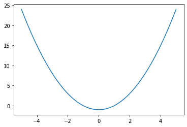

```python
import matplotlib.pyplot as plt
import numpy as np

# get 1000 numbers between -5 and 5
xs = np.linspace(-5, 5, 1000)

# apply a function on this numpy array
ys = xs ** 2 - 1

# show a figure
plt.plot(xs, ys)
plt.show()
```

```python
import pandas as pd

# quickly read a csv file
df = pd.read_csv("./datasets/iris.csv")
df
```

|  | 5.1 | 3.5 | 1.4 | 0.2 | Iris-setosa |
| --- | --- | --- | --- | --- | --- |
| 0 | 4.9 | 3.0 | 1.4 | 0.2 | Iris-setosa |
| 1 | 4.7 | 3.2 | 1.3 | 0.2 | Iris-setosa |
| 2 | 4.6 | 3.1 | 1.5 | 0.2 | Iris-setosa |
| 3 | 5.0 | 3.6 | 1.4 | 0.2 | Iris-setosa |
| 4 | 5.4 | 3.9 | 1.7 | 0.4 | Iris-setosa |
| ... | ... | ... | ... | ... | ... |
| 144 | 6.7 | 3.0 | 5.2 | 2.3 | Iris-virginica |
| 145 | 6.3 | 2.5 | 5.0 | 1.9 | Iris-virginica |
| 146 | 6.5 | 3.0 | 5.2 | 2.0 | Iris-virginica |
| 147 | 6.2 | 3.4 | 5.4 | 2.3 | Iris-virginica |
| 148 | 5.9 | 3.0 | 5.1 | 1.8 | Iris-virginica |

149 rows × 5 columns

# 💎 Zen of Python

```python
# if you ever need help with something, use `help` ... or, ask Google
help(sorted)
```

```
Help on built-in function sorted in module builtins:

sorted(iterable, /, *, key=None, reverse=False)
    Return a new list containing all items from the iterable in ascending order.

    A custom key function can be supplied to customize the sort order, and the
    reverse flag can be set to request the result in descending order.
```

```python
import this
```

```
The Zen of Python, by Tim Peters

Beautiful is better than ugly.
Explicit is better than implicit.
Simple is better than complex.
Complex is better than complicated.
Flat is better than nested.
Sparse is better than dense.
Readability counts.
Special cases aren't special enough to break the rules.
Although practicality beats purity.
Errors should never pass silently.
Unless explicitly silenced.
In the face of ambiguity, refuse the temptation to guess.
There should be one-- and preferably only one --obvious way to do it.
Although that way may not be obvious at first unless you're Dutch.
Now is better than never.
Although never is often better than *right* now.
If the implementation is hard to explain, it's a bad idea.
If the implementation is easy to explain, it may be a good idea.
Namespaces are one honking great idea -- let's do more of those!
```

```python
# import antigravity
# go ahead, try it ;)
```